# Assignment-5 Indian Statistical Inst-Hyderabad

Certification program on Business Analytics

Mallesham Yamulla

# *Statistical Inferences on Toyota cars and Health data*

*The below given necessary R packages have been made use of to carry out the statistical test and bring up inferences*

```r
library(infer)
library(tidyverse)
library(ggplot2)
library(readxl)
```

## Toyota Cars data

### Observation- 1

###### *Null hypothesis:* The avg.sale price is the same for power steering and non-powersteering cars

###### *Alternate hypothesis:* The avg. sale price of powersteering cars is higher than the non powersteering cars

```r
Totoya_hyp1 <- Toyota_isi %>% filter(!is.na(Power_Steering),!is.na(Price))%>% select(Power_Steering,Price) %>% mutate(Power_Steering=factor(Power_Steering))

#Generate 1000 differences in means via randomization

null_distribution_toyota_ste <- Totoya_hyp1  %>%
  specify(Price ~ Power_Steering) %>%
  hypothesize(null = "independence") %>%
  generate(reps = 1000, type = "permute") %>%
  calculate(stat = "diff in means", order = c("1", "0"))

#  Calulcate diff in observed means

obs_stat_toyota_ste <- Totoya_hyp1  %>%
  group_by(Power_Steering) %>%
  summarize(mean = mean(Price)) %>%
  summarize(obs_stat = diff(mean)) %>%
  pull(obs_stat)


# P value

null_distribution_toyota_ste %>%
  filter(stat>obs_stat_toyota_ste) %>%
  summarize(p_val = n() / 1000) %>%
  pull()
```

```
## [1] 0.002
```

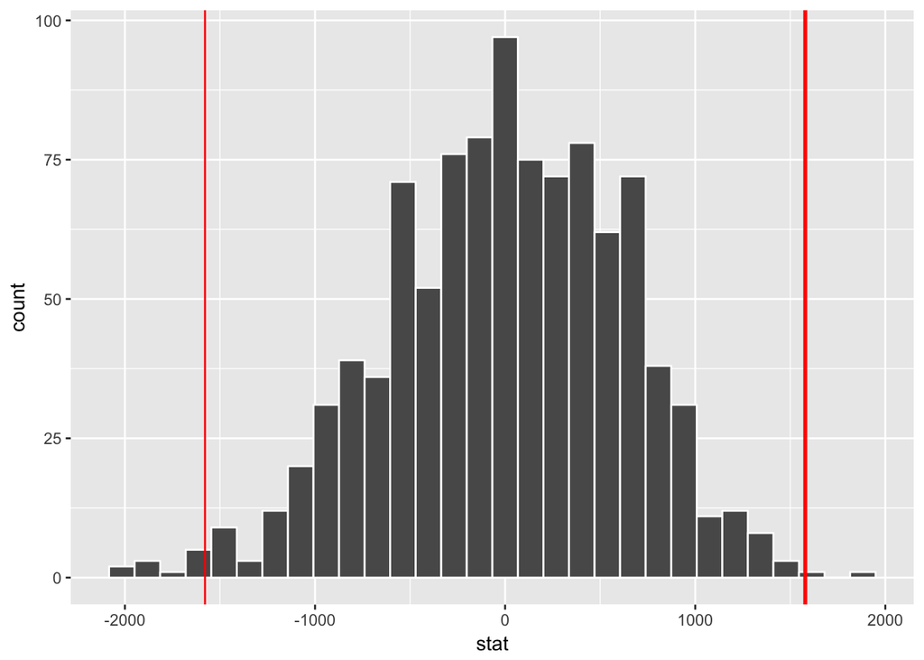

```r
# Visualization

plot_ste <- null_distribution_toyota_ste %>%
  visualize()

plot_ste + geom_vline(xintercept = obs_stat_toyota_ste, col = "red", size = 1) + geom_vline(color = "red", xintercept = -obs_stat_toyota_ste)
```

### Observation- 2

###### *Null hypothesis:* The avg.sale price is the same for sports model and normal cars

###### *Alternate hypothesis:* The avg. sale price of sports model cars is higher than the normal cars

```r
Totoya_hyp2 <- Toyota_isi %>% filter(!is.na(Sport_Model),!is.na(Price))%>% select(Sport_Model,Price) %>% mutate(Sport_Model=factor(Sport_Model))

#Generate 1000 differences in means via randomization

null_distribution_toyota_model <- Totoya_hyp2  %>%
  specify(Price ~ Sport_Model) %>%
  hypothesize(null = "independence") %>%
  generate(reps = 1000, type = "permute") %>%
  calculate(stat = "diff in means", order = c("0", "1"))

#  Calulcate diff in observed means
obs_stat_toyota_model <- Totoya_hyp2  %>%
  group_by(Sport_Model) %>%
  summarize(mean = mean(Price)) %>%
  summarize(obs_stat = diff(mean)) %>%
  pull(obs_stat)

# P value

null_distribution_toyota_model %>%
  filter(stat>obs_stat_toyota_model) %>%
  summarize(p_val = n() / 1000) %>%
  pull()
```

```
## [1] 0
```

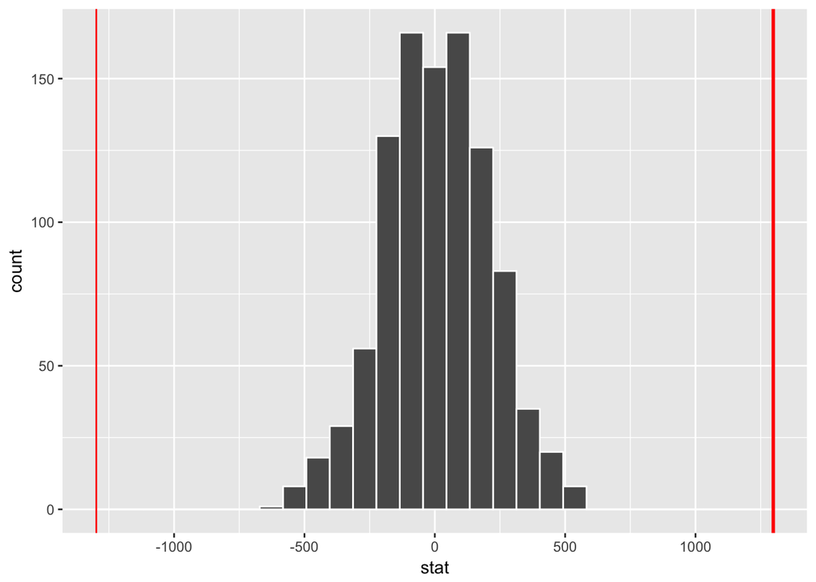

```r
# Visualization

plot_model <- null_distribution_toyota_model %>%
  visualize()
plot_model + geom_vline(xintercept = obs_stat_toyota_model, col = "red", size = 1) + geom_vline(color = "red", xintercept = -obs_stat_toyota_model)
```

> P value caluclated as 0 which is also lesser than significance level 0.05, hence we reject the null hypothesis

### Observation - 3

###### *Null hypothesis:* The median price of a car 10000 Euros

###### *Alternate hypothesis:* The median price of a car is greater than 10000 Euros

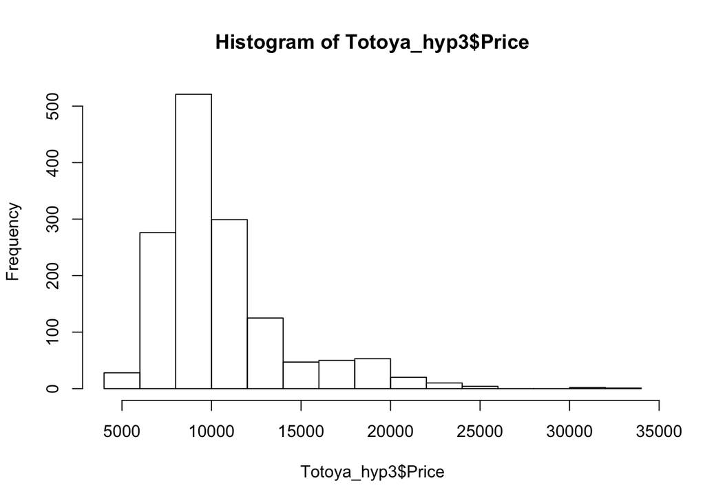

```r
Totoya_hyp3 <- Toyota_isi %>% filter(!is.na(Weight),!is.na(Price))%>% select(Price)

# Visualizing the distribution of data

hist(Totoya_hyp3$Price)
```

```r
# Generate 1000 bootstrap samples centered at null

null_distribution_toyota_price <- Totoya_hyp3 %>%
  specify(response=Price) %>%
  hypothesize(null = "point",med=10000) %>%
  generate(reps = 1000, type = "bootstrap") %>%
  calculate(stat = "median")

# Calculate observed median
obs_median_price <-  Totoya_hyp3%>%
    summarize(median(Price)) %>%
    pull()

# P- Value

null_distribution_toyota_price %>%
  filter(stat>obs_median_price) %>%
  summarize(p_val = n() / 1000) %>%
  pull()
```

```
## [1] 0.733
```

```r
# Determine critical value
t_star <- qt(0.975, df = nrow(Totoya_hyp3) - 1)

# Calculate the 95% CI via standard error method

null_distribution_toyota_price %>%
  summarize(boot_se = sd(null_distribution_toyota_price$stat)) %>%
  summarize(l = obs_median_price - t_star * boot_se,
            u = obs_median_price + t_star * boot_se)
```

```
## # A tibble: 1 x 2
##          l        u
##      <dbl>    <dbl>
## 1 9753.235 10046.76
```

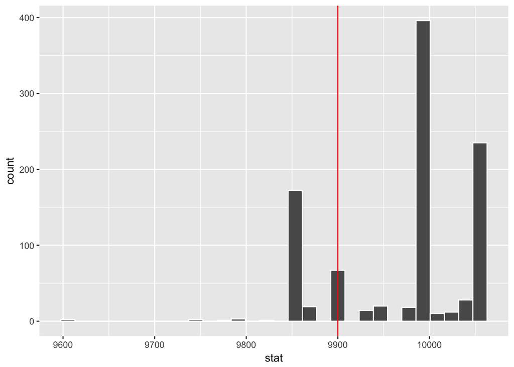

```r
# Visualization

toyota_price_plot <- null_distribution_toyota_price %>%
                    visualize()

toyota_price_plot + geom_vline(aes(xintercept=obs_median_price),col="red")
```

> P value caluclated is greater than significance level 0.05, hence we fail to reject the null hypothesis.

### Observation - 4

###### *Null hypothesis:* The median weight of a car is about 1000Kgs

###### *Alternate hypothesis:* The median weight of a car is greater than 1000Kgs

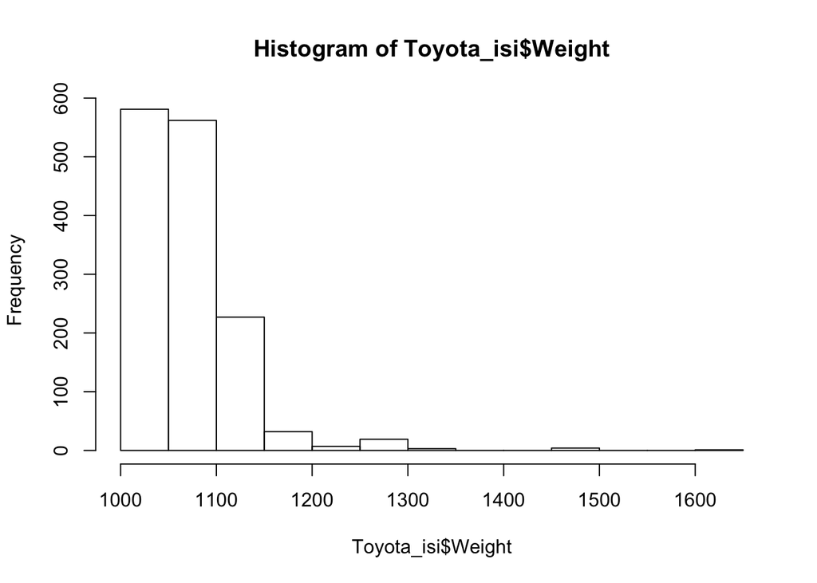

```r
# Visualizing the distribution of data

hist(Toyota_isi$Weight)
```

```r
# Generate 1000 bootstrap samples centered at null
null_distribution_toyota_weight <- Toyota_isi %>%
  specify(response = Weight) %>%
  hypothesize(null = "point", med = 1000) %>%
  generate(reps = 1000, type = "bootstrap") %>%
  calculate(stat = "median")


# Calculate observed median
toyota_w_med_obs <- Toyota_isi %>%
  summarize(median(Weight)) %>%
  pull()

# P- Value

null_distribution_toyota_weight %>%
  filter(stat > toyota_w_med_obs) %>%
  summarize(n() / 1000) %>%
  pull()
```

```
## [1] 0
```

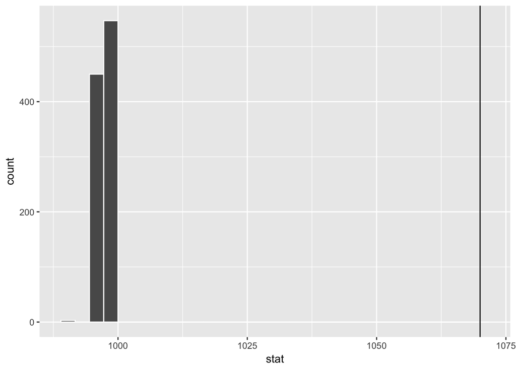

```r
# Visualization

toyota_weight_plot <- null_distribution_toyota_weight %>%
  visualize()

toyota_weight_plot + geom_vline(aes(xintercept=toyota_w_med_obs))
```

> P value caluclated as 0 which also lesser than significance level 0.05, hence we reject the null hypothesis

### Observation - 5

###### *Null hypothesis:* The avg horsepower of a car is about 101

###### *Alternate hypothesis:* The avg horsepower of a car is greater than 101

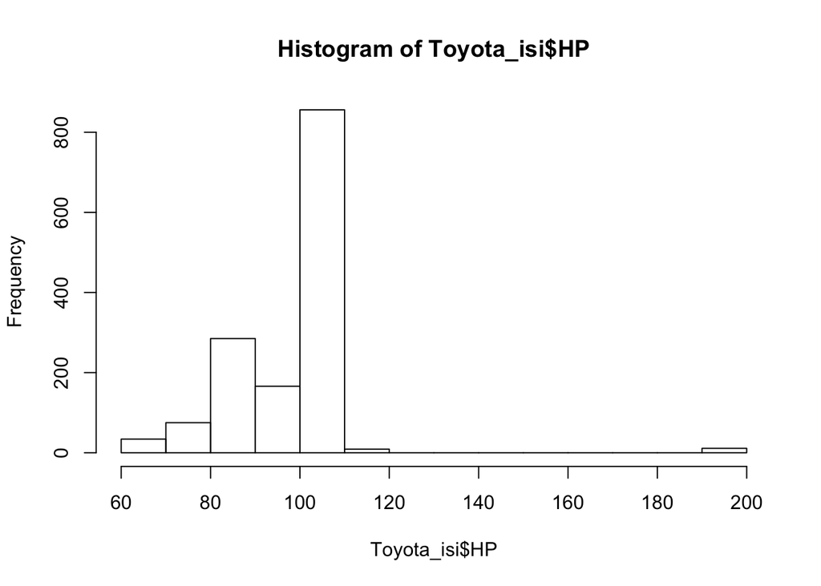

```r
# Visualizing the distribution of data
hist(Toyota_isi$HP)
```

```r
# Generate 1500 bootstrap samples centered at null

null_distribution_toyota_hp <- Toyota_isi %>%
  filter(!is.na(HP)) %>%
  specify(response = HP) %>%
  hypothesize(null = "point", mu = 101) %>%
  generate(reps = 1500, type = "bootstrap") %>%
  calculate(stat = "mean")

# Calculate observed mean
Toyota_hp_mean_obs <- Toyota_isi %>%
  summarize(mean(HP,na.rm = TRUE)) %>%
  pull()

# Calculate p-value
null_distribution_toyota_hp %>%
  filter(stat > Toyota_hp_mean_obs) %>%
  summarize(n() / 1500) %>%
  pull()
```

```
## [1] 0.118
```

```r
# Determine critical value
t_star <- qt(0.975, df = nrow(salud_limpiado) - 1)

# Calculate the 95% CI via standard error method

null_distribution_toyota_hp %>%
  summarize(boot_se = sd(null_distribution_toyota_hp$stat)) %>%
  summarize(l = Toyota_hp_mean_obs - t_star * boot_se,
            u = Toyota_hp_mean_obs + t_star * boot_se)
```

```
## # A tibble: 1 x 2
##         l        u
##     <dbl>    <dbl>
## 1 100.708 102.2962
```

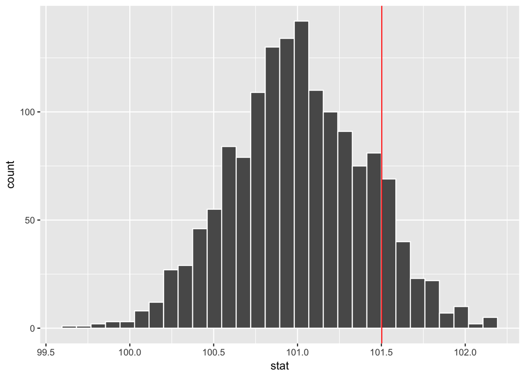

```r
# Visualization

toyota_hp_plot <- null_distribution_toyota_hp %>%
  visualize()

toyota_hp_plot + geom_vline(aes(xintercept=Toyota_hp_mean_obs),col="red")
```

> P value caluclated is higher than significance level 0.05, hence we fail reject the null hypothesis.

> We see that 101 is contained in this confidence interval as a plausible value of μ(the unknown population mean) and .This matches with our hypothesis test results of failing to reject the null hypothesis

### Observation - 6

###### *Null hypothesis:* The median Accumulated Kilometers on odometer of a car is about 50000

###### *Alternate hypothesis:* The median Accumulated Kilometers on odometer of a car is greater than 50000

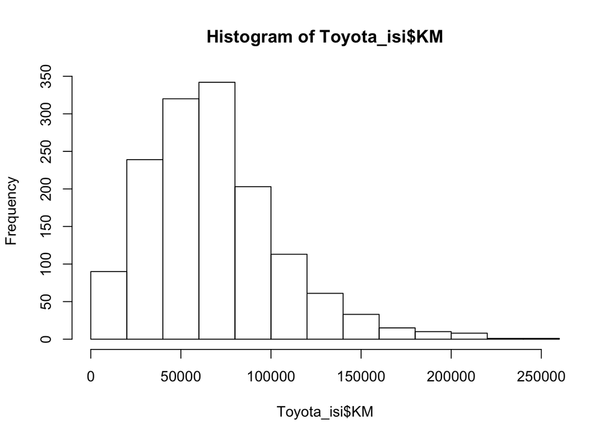

```r
# Visualizing the distribution of data

hist(Toyota_isi$KM)
```

```r
# Generate 1500 bootstrap samples centered at null
null_distribution_toyota_km <- Toyota_isi %>%
  filter(!is.na(KM)) %>%
  specify(response = KM) %>%
  hypothesize(null = "point", med = 50000) %>%
  generate(reps = 1500, type = "bootstrap") %>%
  calculate(stat = "median")


# Calculate observed median
toyota_k_med_obs <- Toyota_isi %>%
  summarize(median(KM,na.rm = TRUE)) %>%
  pull()


# P- Value
null_distribution_toyota_km %>%
  filter(stat > toyota_k_med_obs) %>%
  summarize(n() / 1500) %>%
  pull()
```

```
## [1] 0
```

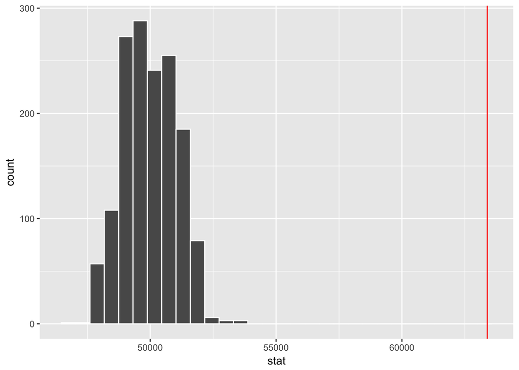

```r
# Visualization
Toyota_hyp_k_plot <- null_distribution_toyota_km %>% visualize()

Toyota_hyp_k_plot + geom_vline(aes(xintercept=toyota_k_med_obs),col="red")
```

> P value caluclated as 0 which also lesser than significance level 0.05, hence we reject the null hypothesis

## Health data

### Observation- 1

###### *Null hypothesis:* The avg.weight of a male/female candiade is about 70

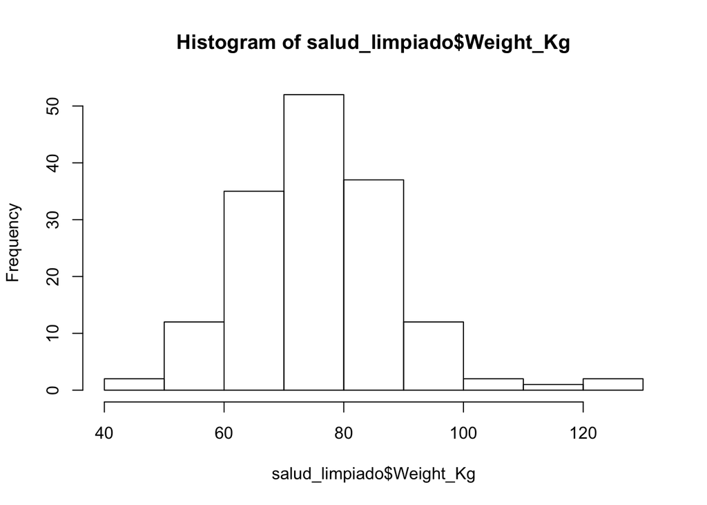

```r
# View the distribution of data

hist(salud_limpiado$Weight_Kg)
```

```r
#Generate 100 bootstrap samples centered at null

salud_weight_test <- salud_limpiado %>%
      specify(response = Weight_Kg) %>%
      hypothesize(null = "point", mu = 70) %>%
      generate(reps = 100,type = "bootstrap") %>%
      calculate(stat="mean")

# Calculate observed mean
salud_w_me_obs <- salud_limpiado%>%
  # Calculate observed median rent
  summarize(mean(Weight_Kg)) %>%
  # Extract numerical value
  pull()

# P value
salud_weight_test %>%
  filter(stat > salud_w_me_obs) %>%
  summarize(n() / 100) %>%
  pull()
```

```
## [1] 0
```

```r
# Determine critical value
t_star <- qt(0.975, df = nrow(salud_limpiado) - 1)

# Calculate the 95% CI via standard error method

salud_weight_test %>%
  summarize(boot_se = sd(salud_weight_test$stat)) %>%
  summarize(l = salud_w_me_obs - t_star * boot_se,
            u = salud_w_me_obs + t_star * boot_se)
```

```
## # A tibble: 1 x 2
##          l        u
##      <dbl>    <dbl>
## 1 74.06225 78.09517
```

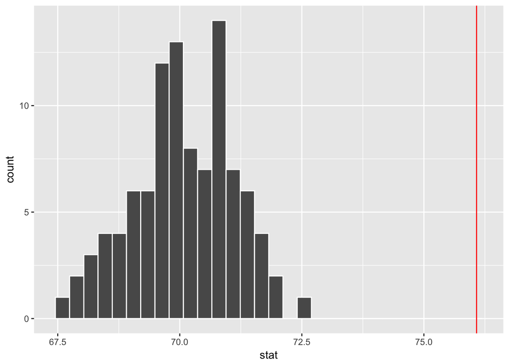

```r
# Visualization- weight

salud_w_plot <- salud_weight_test %>% visualize()

salud_w_plot + geom_vline(aes(xintercept=salud_w_me_obs),color="red")
```

> P value caluclated as 0 which also lesser than significance level 0.05, hence we reject the null hypothesis

> We see that 70 is not contained in this confidence interval as a plausible value of μ(the unknown population mean) and the entire interval is larger than 70. This matches with our hypothesis test results of rejecting the null hypothesis in favor of the alternative

### Observation - 2

###### *Null hypothesis:* The avg.BMI levels a male/female candidate is about 26.5

###### *Alternate hypothesis:* The avg.BMI levels a male/female candidate is more than 26.5

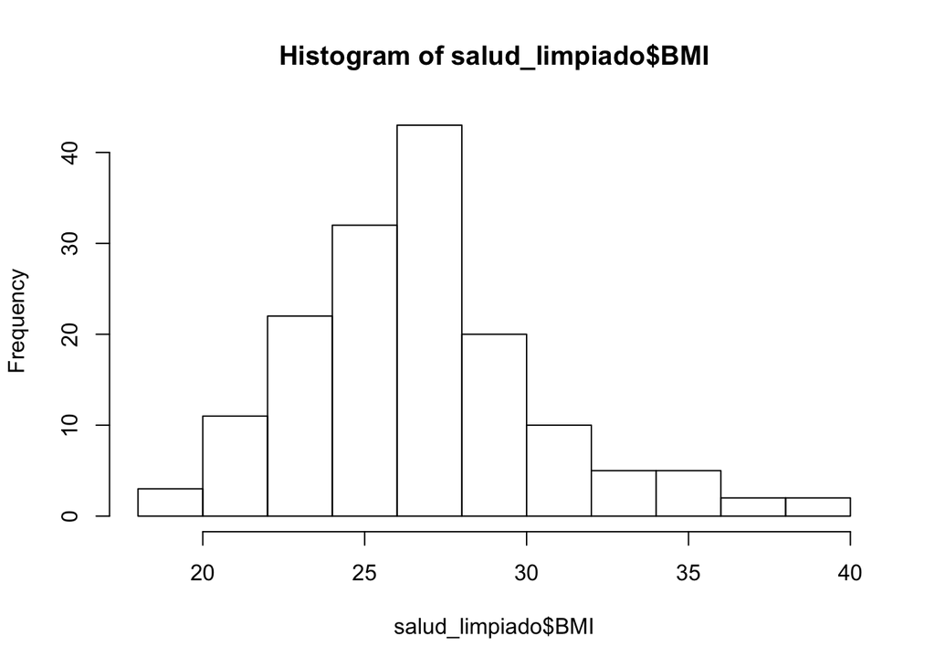

```r
# View the distribution of data

hist(salud_limpiado$BMI)
```

```r
#Generate 200 bootstrap samples centered at null

salud_bmi_test <- salud_limpiado %>%
  specify(response = BMI) %>%
  hypothesize(null = "point", mu = 26.5) %>%
  generate(reps = 200,type = "bootstrap") %>%
  calculate(stat="mean")

# Calculate observed mean

salud_bm_me_obs <- salud_limpiado%>%
  summarize(mean(BMI)) %>%
  # Extract numerical value
  pull()


# P-Value

salud_bmi_test %>%
  filter(stat > salud_bm_me_obs) %>%
  summarize(n() / 200) %>%
  pull()
```

```
## [1] 0.275
```

```r
# Determine critical value
t_star <- qt(0.975, df = nrow(salud_limpiado) - 1)

# Calculate the 95% CI via standard error method

salud_weight_test %>%
  summarize(boot_se = sd(salud_bmi_test$stat)) %>%
  summarize(l = salud_bm_me_obs - t_star * boot_se,
            u = salud_bm_me_obs + t_star * boot_se)
```

```
## # A tibble: 1 x 2
##          l        u
##      <dbl>    <dbl>
## 1 26.08823 27.29242
```

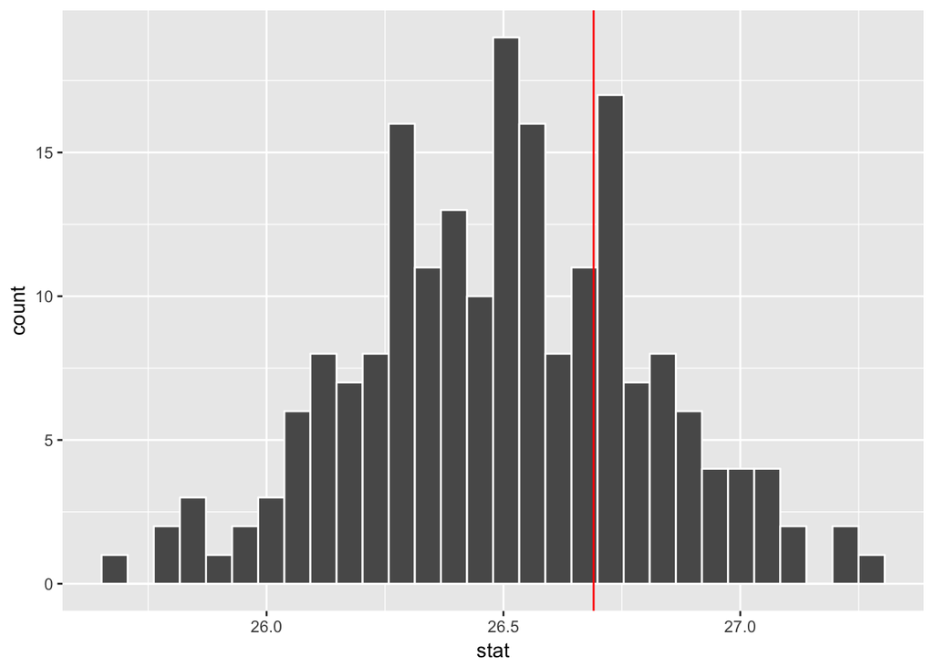

```r
# Visualization- BMI

salud_bmi_plot <- salud_bmi_test %>% visualize()

salud_bmi_plot+ geom_vline(aes(xintercept=salud_bm_me_obs),color="red")
```

> P value caluclated is higher than significance level 0.05, hence we fail to reject the null hypothesis.

> We see that 26.5 is contained in this confidence interval as a plausible value of μ(the unknown population mean), This matches with our hypothesis test results of failing to raject the null hypothesis.

### Observation -3

###### *Null hypothesis:* The avg.Waist a male/female candidate is about 92cms

###### *Alternate hypothesis:* The avg.Waist a male/female candidate is higher than 92cms

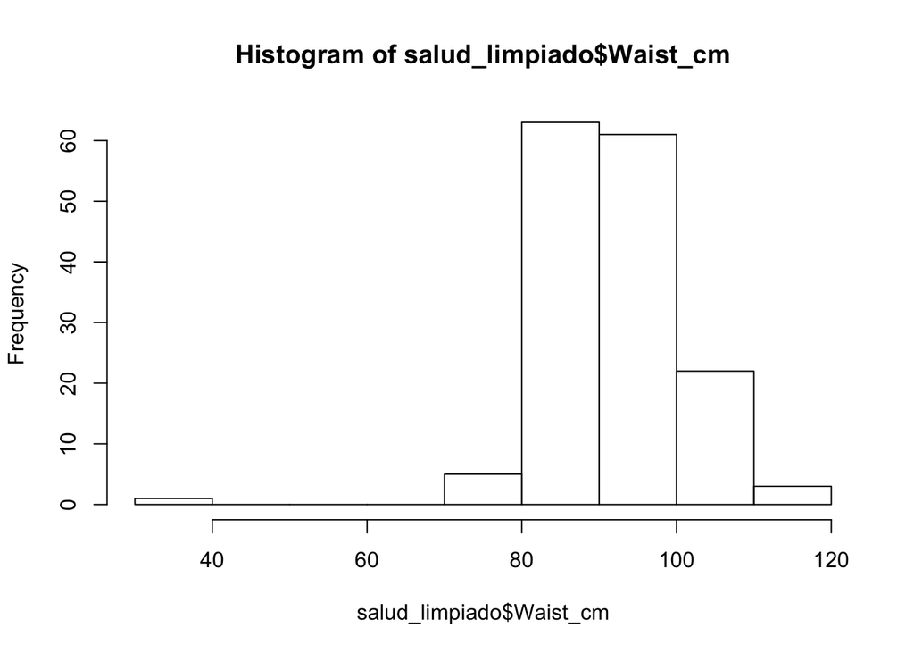

```r
# View the distribution of data

hist(salud_limpiado$Waist_cm)
```

```r
#Generate 200 bootstrap samples centered at null
salud_we_test <- salud_limpiado %>%
  specify(response = Waist_cm) %>%
  hypothesize(null = "point", mu= 92) %>%
  generate(reps = 200,type = "bootstrap") %>%
  calculate(stat="mean")


# Calculate observed mean

salud_we_me_obs <- salud_limpiado%>%
  summarize(mean(Waist_cm)) %>%
  # Extract numerical value
  pull()

# P- Value
salud_we_test %>%
  filter(stat > salud_we_me_obs) %>%
  summarize(n() / 200) %>%
  pull()
```

```
## [1] 0.415
```

```r
# Determine critical value
t_star <- qt(0.975, df = nrow(salud_limpiado) - 1)

# Calculate the 95% CI via standard error method

salud_weight_test %>%
  summarize(boot_se = sd(salud_we_test$stat)) %>%
  summarize(l = salud_we_me_obs - t_star * boot_se,
            u = salud_we_me_obs + t_star * boot_se)
```

```
## # A tibble: 1 x 2
##          l       u
##      <dbl>   <dbl>
## 1 90.70816 93.6521
```

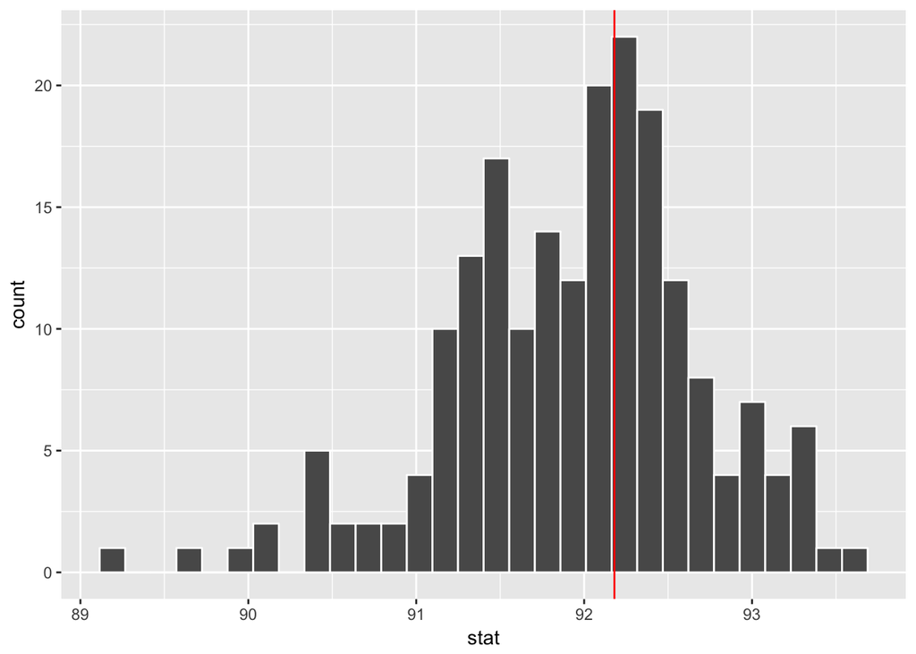

```r
# Visualiation - Waist
salud_we_plot <- salud_we_test %>% visualize()

salud_we_plot + geom_vline(aes(xintercept=salud_we_me_obs),col="red")
```

> P caluclated value is higher than significance level 0.05, hence we fail to reject the null hypothesis.

> We see that 92 is contained in this confidence interval as a plausible value of μ(the unknown population mean), This matches with our hypothesis test results of failing to raject the null hypothesis

### Observation -4

###### *Null hypothesis:* The avg.Height a male/female candidate is about 160cms

###### *Alternate hypothesis:* The avg.Height a male/female candidate is higher than about 160cms

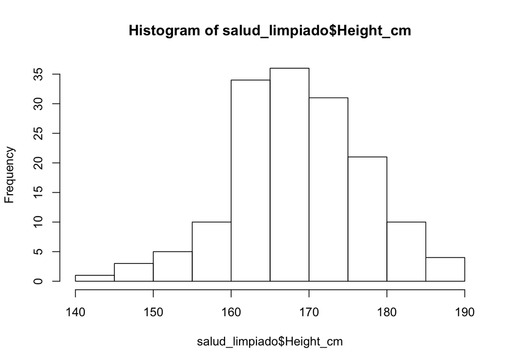

```r
# Visualizing the dsitribution of data

hist(salud_limpiado$Height_cm)
```

```r
# Generate 1000 bootstrap samples centered at null

salud_he_test <- salud_limpiado %>%
  specify(response = Height_cm) %>%
  hypothesize(null = "point", mu= 160) %>%
  generate(reps = 1000,type = "bootstrap") %>%
  calculate(stat="mean")

# Calculate observed mean
salud_he_me_obs <- salud_limpiado%>%
  summarize(mean(Height_cm)) %>%
  # Extract numerical value
  pull()

# P- value

salud_he_test %>%
  filter(stat > salud_he_me_obs) %>%
  summarize(n() / 1000)
```

```
## # A tibble: 1 x 1
##   `n()/1000`
##        <dbl>
## 1          0
```

```r
# Determine critical value
t_star <- qt(0.975, df = nrow(salud_limpiado) - 1)

# Calculate the 95% CI via standard error method

salud_weight_test %>%
  summarize(boot_se = sd(salud_he_test$stat)) %>%
  summarize(l = salud_he_me_obs - t_star * boot_se,
            u = salud_he_me_obs + t_star * boot_se)
```

```
## # A tibble: 1 x 2
##          l        u
##      <dbl>    <dbl>
## 1 167.7786 170.3956
```

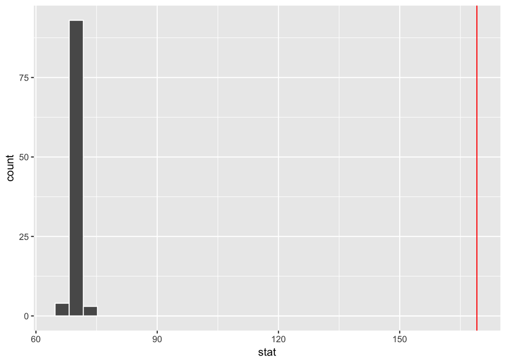

```r
# Visualization - Height

salud_weight_plot <- salud_weight_test %>% visualize()

salud_weight_plot + geom_vline(aes(xintercept=salud_he_me_obs),color="red")
```

> P value caluclated as 0 which also lesser than significance level 0.05, hence we reject the null hypothesis

> We see that 160 is not contained in this confidence interval as a plausible value of μ(the unknown population mean) and the entire interval is larger than 160.This matches with our hypothesis test results of rejecting the null hypothesis in favor of the alternative

### Observation - 5

###### *Null hypothesis:* The avg BMI levels are equal in male and female groups

###### *Alternate hypothesis:* The avg BMI levels are not same in male and female groups

```r
# Generate 1000 differences in means via randomization
salud_bmi_mean <- salud_limpiado %>%
  specify(BMI ~ Sex) %>%
  # Null = no difference between means
  hypothesize(null = "independence") %>%
  # Shuffle labels 1000 times
  generate(reps = 1000, type = "permute") %>%
  # Calculate test statistic
  calculate(stat = "diff in means", order = c("M","F"))

#  Calulcate diff in observed means
salud_dif_bmi <- salud_limpiado%>%
  group_by(Sex) %>%
  summarize(mean_bmi = mean(BMI)) %>%
  # Extract
  pull() %>%
  # Calculate difference
  diff()

# Calculate p-value
salud_bmi_mean %>%
  # Identify simulated test statistics at least as extreme as observed
  filter(stat < salud_dif_bmi) %>%
  # Calculate p-value
  summarize(p_val = (n() / 1000) * 2) %>%
  pull()
```

```
## [1] 1.862
```

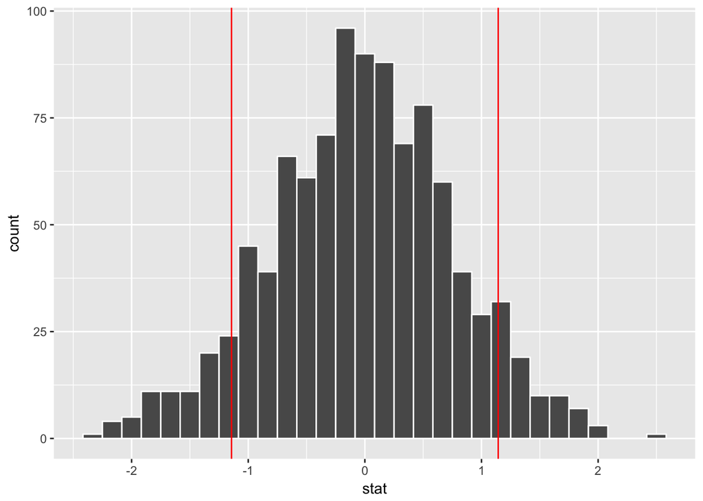

```r
# Visualization - two means sex vs bmi

salud_gen_bmi <- salud_bmi_mean %>% visualize()

salud_gen_bmi + geom_vline(aes(xintercept=salud_dif_bmi),col="red") + geom_vline(aes(xintercept=-salud_dif_bmi),col="red")
```

> we fail to reject the null hypothesis since the caluclated p value is higher than the significance level 0.05

## A Systematic Approach for Business Data Analytics with a Real Case Study

### Proposed systematic approach to business data analytics

An effective business data analytics team would be composed of

- Business experts
- InformationTechnolgy experts
- Data analysis experts

These three types of experts need to collaborate and work closely with each other in the proposed analytics process that is explained step-by-step below.

1. Bunisess strategy
2. Integration of Model Identification and Data Acquisition
3. Visualization
4. Uncertainity analysis
5. Decision makng

###### **Bunisess strategy**

Organizations should start the business data analytics from identifying the current priority challenge such as improving customer experience or building up a new product, which if successfully solved, can bring the highest profit to the company.

###### **Integration of Model Identification and Data Acquisition**

Once the business strategy is identified, the second step is to identify the appropriate model and acquire the right data to achieve the business strategy. These two elements, model identification and data acquisition, are needed to be seamlessly integrated together to optimize the data analytics process.

###### **Visualization**

Visualization is the next step that focuses on quickly distilling the potentially huge amounts of data and transferring them into salient results that can be readily understood by everyone in the business data analytics team. Although the concept of visualization is not new, its value and use are often overlooked and poorly imple- mented in practice during the business decision making process.

###### **Uncertainity analysis**

A strong visualization should advance users’ understanding about their business performance and provide direct answers to the identified busi- ness strategy. However, before making the right decision, it is necessary to conduct uncertainty analysis to thoroughly understand the risk of such a potential action. The uncertainty stems from two aspects of the business data analytics: data uncertainty and model uncertainty. Data uncertainty is due to the poor quality of busi- ness data and the assumptions made to cross reference the proprietary business performance data with public database as mentioned before. Model uncertainty involves the risks of the model specification and the estimated param- eters inside the model.

###### **Decision making**

Based on the result of uncertainty analysis, robust decision-making process can be achieved accordingly. There are some decisions that need to be made regularly (example: introducing new features in a produt). In such case, business data analytics process is required to be incorporated with real-time information and conducted in a timely manner, such that the right decision can be delivered to the right group of cus- tomers at the right time. On the other hand, some decisions are like one-step move such as purchasing the competitor’s company. For this kind of decision-making process, a set of back-up plans usually needs to be prioritized in case some emergency situations occur. The decision-making process should be well aligned with the identified business strategy in the step 1. Any discrepancies require iterating the whole business data analytics process until a unified scheme is finally achieved

###### **Conclusion**

With the massive growth of “big data” in busi- ness operations, it becomes vitally important to take advantage of the business analytics tools to effectively assess, analyze and visual- ize the data to transform from data-rich into decision-smart.

Three fundamental challenges in business data analytics are as follows,

1. *Business data often encounters quality issues and needs substantial cleaning efforts before making any of sense*
2. *Business data is large in overall size but cannot be fully shared due to the concern of data security at the company*
3. *Business data often needs to be cross-referenced with public databases to reveal more information and knowledge*

## The evolving-role-data-decision-making

One term we will frequently hear in relation to data analytics teams is data-driven, it’s a little bit of tricky term. we all like to use data to drive our decisions. if we dicide not to eat a burger from a bakery it’s based on real data

Here, we are using past experience and maybe some observations to make a good decision. More often than not, our intuition is right or atleast half right. try not to think of data-driven decision making as a drop in replacement for our own intuition.

A data driven cultute uses data to enhance the teams intuition,not to replace it.

Our data analytics team will be the starting point for creating a larger data analyics mindset that has a deeped relationship with data.Try to think of data driven organizations as companies with many data science teams reinforcing a data analytics mindset.

These teams create a culture of questions and insight.they should help the orgnization not only collect data, but also make it actionable.

A data analytics team will have three major areas o responsibilities, these three areas create the foundation for our data analytics team which will help the rest of our organization embrace this new mindset, they are:

1. *Collecting accessing and reporting data*

This involves processing the raw data into something that everyonce else can understand

2. *Asking good questions*

This drives interesting data experiments and may come from the team members who don’t necessarily have a technology background. they can be from business, marketing or managament. they ask interesting business questions and push every one to their assumptions.

3. ***Making the data actionable**

This will be the responsibilty of team members who are primarily concerned with what the team has learned and how this data can be applied to the organization.